# Effects of User Characteristics ( ages-types-gender) on Trip Durations

## by sally hamed

## Investigation Overview

> In this investigation, I wanted to look at the characteristics of users that could be used to predict their bike trip duration. The main focus was on the user characteristics : ages, users type, gender, and thier bike trip distances.

## Dataset Overview

> The data consisted of 174880 bike trip in the dataset with 20 features. The attributes included the user characteristics, as well as additional measurements such as age of customer and distance of biking trip that I find necessary to perform analysis.

## Distribution of Trip Duration

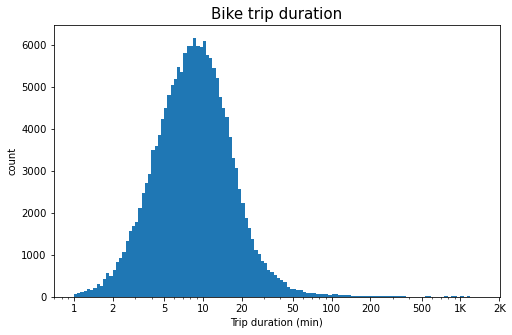

## Distribution of Distance

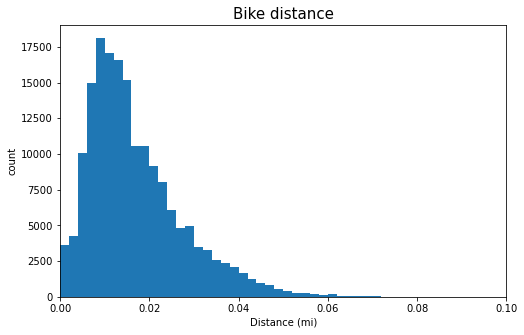

# Distribution of User Characteristics

the distributions show:

- The number of male larger than the number of female and the other.
- The number of subscriber largely exceeds that of customer. This indicates good relationship and satisfactions from the users with the services provided

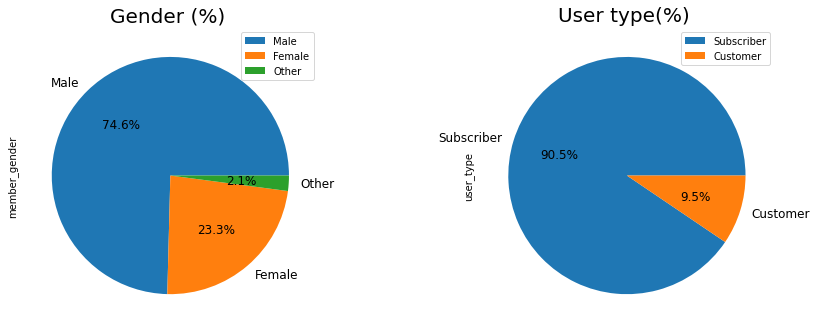

# Distribution of UserType across Gender

> It is clear that the number of subscriber is more than that of the customer,also we can see male subscribers are much more than female subscribers

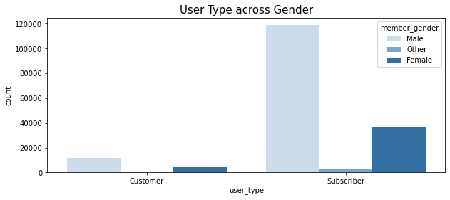